# Laboratorio 3 - POT

### Carolina Crisci, Gonzalo Perera, Angel Segura

# Introducción

En este LAB trabajaremos con el método de Picos sobre el Umbral (POT en inglés por *Peaks over Thresholds*) vistos en el teórico.

El foco de esta técnica está puesto en describir la distribución de los excesos de un determinado umbral ($u$) alto. Esto permite obtener información más detallada que con los métodos de HLE o DEA, ya que no miramos sólo el valor más grande, sino que vemos la distribución de los excesos ($X>u$).  
Este método de POT se apoya en un resultado conocido como el *segundo teorema de la teoría clásica de valores extremos*. El teorema de Pickands-Balkema-de Haan (PBdH) nos indica que considerando una distribución $F$ que admite *DEA*, es decir que pertenece al dominio de atracción maximal de alguna de las distribuciones extremales. Dado un umbral $u>0$, la distribución condicional de excesos, definida por:

$$F_u(x)= P(X \le {u+x / X} >u)= {P(u<X \le u+x) / P(X>u) } = {F(u+x) - F(u) / 1-F(u)} ~~~ \forall ~x \in ~ (0, M_F-u)$$
Entonces, cuando $u \to \infty$, $F_u \to$ a una **Distribución de Pareto Generalizada (DPG)**. Antes de pasar al desarrollo del método de POT y sus aplicaciones, exploremos la DPG.

## Distribucion de Pareto Generalizada (DPG)

La DPG es una familia de distribuciones de probabilidad útil para modelar el comportamiento de las colas (extremos de la distribución). La familia de la función de probabilidad para una variable aleatoria $x$ se define con tres parámetros $\mu$ que define la posición, $\sigma$ que es un parámetro de escala y $\xi$ que es un parámetro de forma:

$$F(\mu,\sigma,\xi,~ x )= 1 - (1+ {\xi(x-\mu) \over \sigma})^{-1/\xi} ~~~si ~~~ \xi \ne 0 \\
F(\mu,\sigma,\xi,~ x )= 1 - exp(- {x-\mu \over \sigma}) ~~~~~~~~~~si ~~~ \xi = 0 \\$$

Donde $exp()$ es la función exponencial. Vemos entonces que si el parámetro de forma vale cero, entonces la DGP es una “simple” distribución exponencial (que vimos en el LAB pasado). El parámetro de posición puede tomar cualquier valor real $\mu \in (-\infty,\infty)$, el parámetro de escala es positivo $\sigma \in (0, \infty)$ y la forma puede tomar cualquier valor real $\xi \in (-\infty,\infty)$.

Simulemos en R la función de probabilidad de una variable aleatoria $X \sim {\sf DPG}$ y su densidad para ver como se comporta con algunas combinaciones de parámetros. Como en **R** siempre hay algún paquete que nos sirve para hacer lo que queremos, vamos a cargar el paquete *{VGAM}* que tiene funciones específicas para trabajar con la DPG. Antes de utilizar las funciones pre-establecidas, haremos una figura con la DPG *a mano* para convencernos.

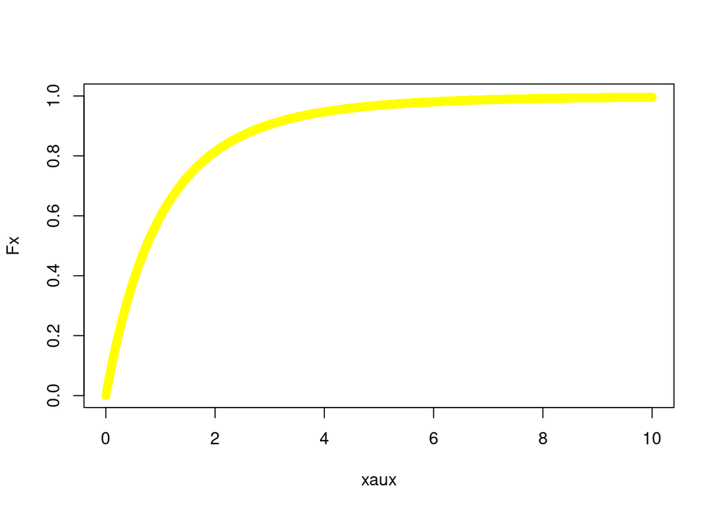

```r
# Defino valores de X auxiliares
xaux<-seq(0,10,length=10000)

# defino los parámetros
xi=0.2
sigma=1
mu=0

# Función de distribución
Fx<-1- (1+ (xi*(xaux-mu)/sigma))^(-1/xi)

plot(xaux, Fx ,col="yellow", ylim=c(0,1))
```

Intente cambiar el $\mu$ a un valor de 2 y genere nuevamente la figura. La idea es que conozcan como se comporta la distribución ante cambios en los parámetros. Recuerden que esta función que definimos de forma manual es **solo** válida para $\xi>0$.

Cargamos el paquete que tiene la función para la DGP y vamos a superponer los valores con los que obtuvimos de forma manual. Recuerden que *pgpd* refiere a la **p**robabilidad de una *gpd* Distribución de Pareto Generalizada (en inglés *Generalized Pareto Distribution*), mientras que *dgpd* refiere a la **d**ensidad de una DPG mientras que *rdgpd* genera números “aleatorios” de una DPG.

```r
#
require(VGAM)
```

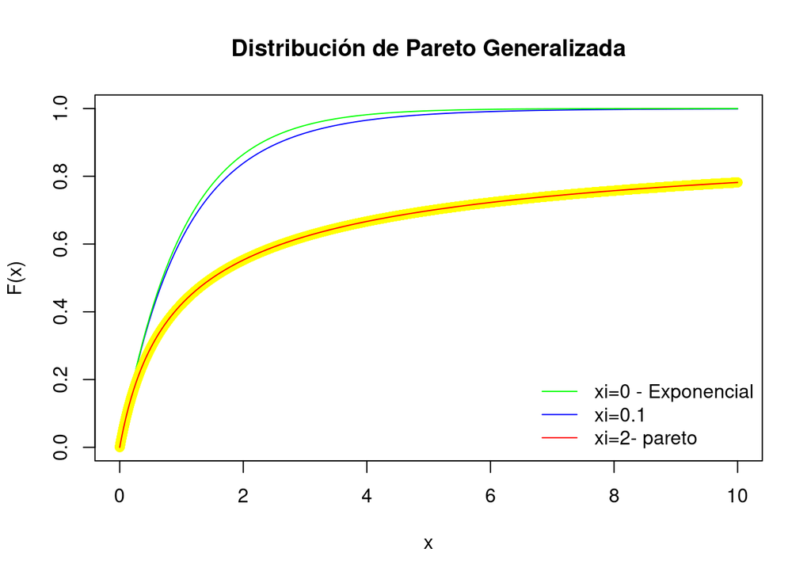

```r
plot(xaux, pgpd(xaux, location=0, scale=1, shape=0.1),type="l", col="blue", ylim=c(0,1), ylab="F(x)", xlab="x", main= "Distribución de Pareto Generalizada")
lines(xaux, pgpd(xaux, location=0, scale=1, shape=0),col="green")
legend("bottomright", legend=c("xi=0 - Exponencial", "xi=0.1", "xi=2- pareto"), bty="n", col=c("green","blue","red"), lty=1)

# funcion a mano
xi=2
sigma=1
mu=0
points(xaux, 1- (1+ (xi*(xaux-mu)/sigma))^(-1/xi),col="yellow")
# función del VGAM
lines(xaux, pgpd(xaux, location=0, scale=1, shape=2),col="red")
```

Ahora veamos la función de densidad de estas mismas DPG usando las funciones del *{VGAM}*.

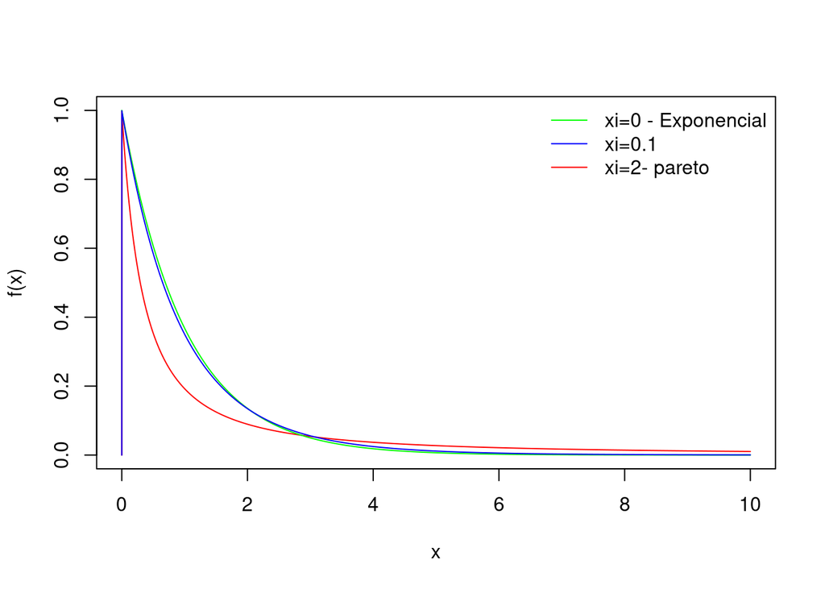

```r
# Densidad (prestar atención a la diferencia con exponencial en las colas)
plot(xaux, dgpd(xaux, location=0, scale=1, shape=2),type="l", col="red", log="", ylim=c(1e-5,1), ylab="f(x)", xlab="x")
lines(xaux, dexp(xaux),col="green")
lines(xaux, dgpd(xaux, location=0, scale=1, shape=0.1),col="blue")
legend("topright", legend=c("xi=0 - Exponencial", "xi=0.1", "xi=2- pareto"), bty="n", col=c("green","blue","red"), lty=1)
```

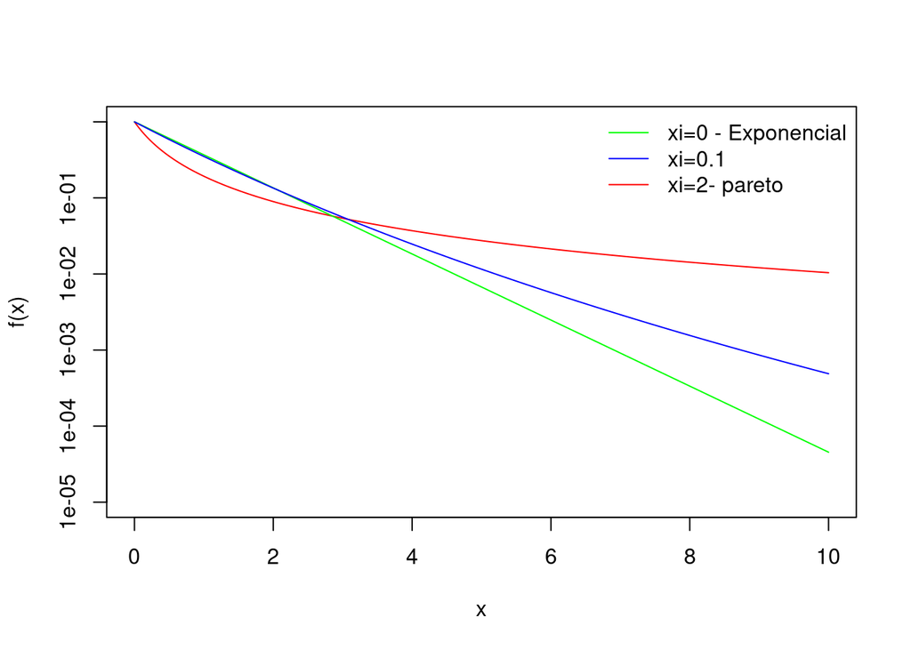

```r
# pongamos el eje Y en escala logaritmica para apreciar mejor el comportamiento en las colas
plot(xaux, dgpd(xaux, location=0, scale=1, shape=2),type="l", col="red", log="y", ylim=c(1e-5,1), ylab="f(x)", xlab="x")
lines(xaux, dexp(xaux),col="green")
lines(xaux, dgpd(xaux, location=0, scale=1, shape=0.1),col="blue")
legend("topright", legend=c("xi=0 - Exponencial", "xi=0.1", "xi=2- pareto"), bty="n", col=c("green","blue","red"), lty=1)
```

Notese que el caso de $\xi=0$ corresponde a una exponencial y por lo tanto en un gráfico semi-logaritmico la función es una recta. El caso de $\xi \approx 0$ se desvía suavemente de la recta, mientras que $\xi > 0$ muestra un fuerte desvío y las probabilidades en las colas (hacia la derecha) caen muy lentamente con respecto a los casos exponenciales.

Veamos resumidos los tres casos paradigmáticos de la DPG que se definen según el valor de $\xi$

- $\xi=0$ es una distribución Exponencial de parámetro ($1/\sigma$) por lo cual $\sigma$ es la media de la distribución
- $\xi = -1$ es una distribución Uniforme ($[0, \sigma]$) cuya media es $\sigma/2$
- $\xi> 0$ es una distribución de Pareto con $\alpha= \xi$

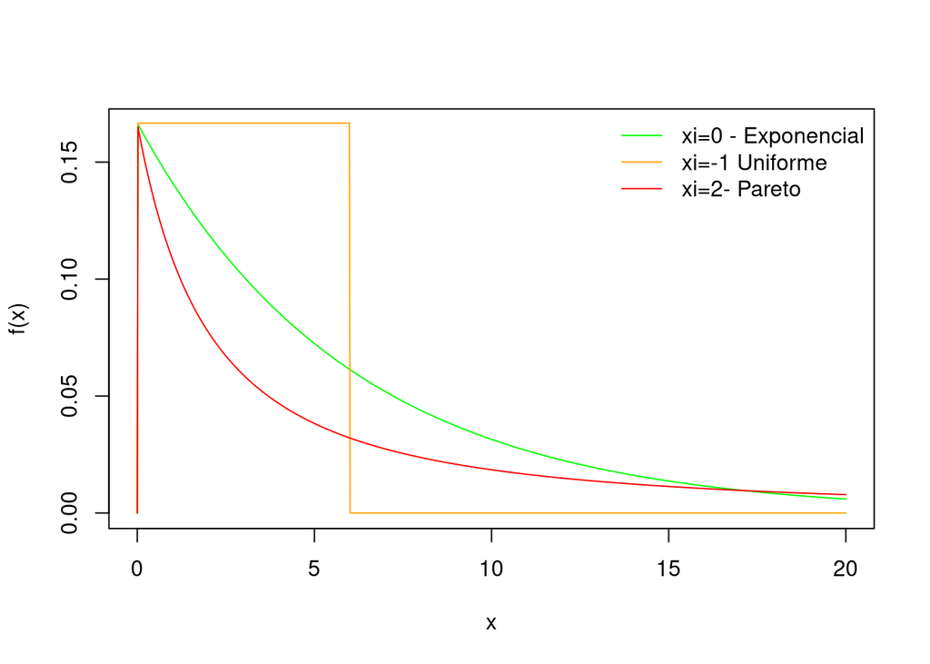

```r
# Densidad (prestar atención a la diferencia con exponencial en las colas)
xaux<-seq(0, 20, length=1000)
plot(xaux, dgpd(xaux, location=0, scale=6, shape=0),type="l", col="green", ylab="f(x)", xlab="x")
lines(xaux, dgpd(xaux, location=0, scale=6, shape=-1),col="orange")
lines(xaux, dgpd(xaux, location=0, scale=6, shape=2),col="red")
legend("topright", legend=c("xi=0 - Exponencial", "xi=-1 Uniforme", "xi=2- Pareto"), bty="n", col=c("green","orange","red"), lty=1)
```

La siguiente función es útil para simular variables aleatórias que sigan una DPG

```r
set.seed(71)
rgpd(20,location=0, scale=1, shape=2) #genero 70 números aleatorios de una variable X con DPG con esos parámetros
```

```
##  [1]  4.01096238  1.12263746  4.16543720 10.65999138  4.50336660  0.05721874
##  [7]  0.64190350  0.13205532  3.87634161  2.14539307 35.66530389  0.36175491
## [13] 24.36810325  0.35012545  0.20502326  0.32872072 27.41761047  0.26978385
## [19]  0.12172092  0.08187460
```

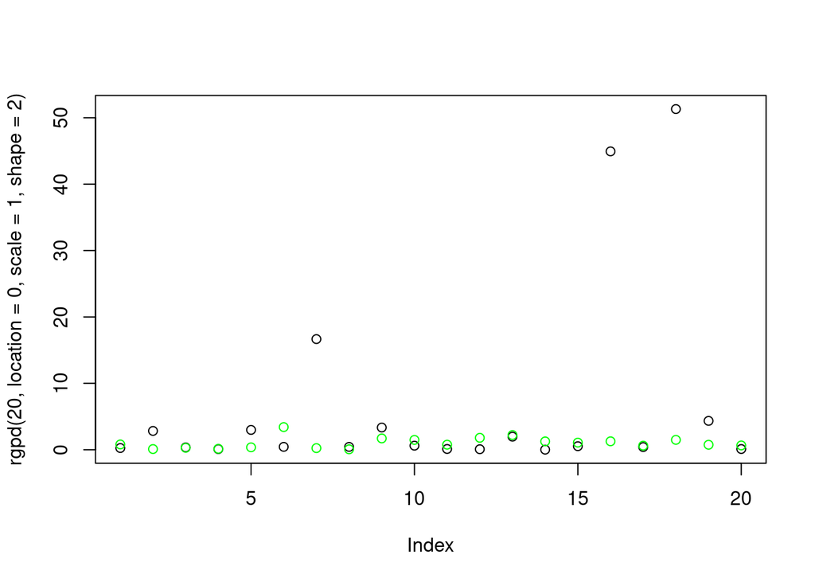

```r
set.seed(233)
plot(rgpd(20,location=0, scale=1, shape=2)) # notese la gran volatilidad pues el parámetro de forma es alto (xi=2)
points(rgpd(20,location=0, scale=1, shape=0.2), col="green")
```

## POT

Siguiendo el teorema de Pickands-Balkema-de Haan (PBdH), sigamos los pasos para implementar POT para datos *iid* que definimos en el teórico.

1. Elegir umbral ($u$) *grande*
2. Estimar la probabilidad de no superar el umbral ($p=F(u)$)
3. Se toma la submuestra que supera el umbral ($x>u$)
4. Se verifica que la submuestra pueda suponerse *iid* mediante las pruebas de aleatoriedad
5. Se verifica que la muestra puede modelarse por una DPG utilizando pruebas de ajuste.
6. Se estiman los parámetros de la DPG (llamemosle $\hat {DPG}$)
7. Si se quiere calcular la probabilidad de que un registro no supera un valor *t* ($t>u$) se calcula $F(t)= p + (1-p)~ \hat {DPG}(t-u)$

### Ejemplos aplicación de POT

Comencemos con un caso sencillo donde se cumplan los supuestos para ejemplificar la forma de proceder para emplear este método (referencia a página 101 del teórico). Luego, en ejemplos posteriores complejizaremos este esquema y veremos casos donde algunos de los supuestos no se cumplen.

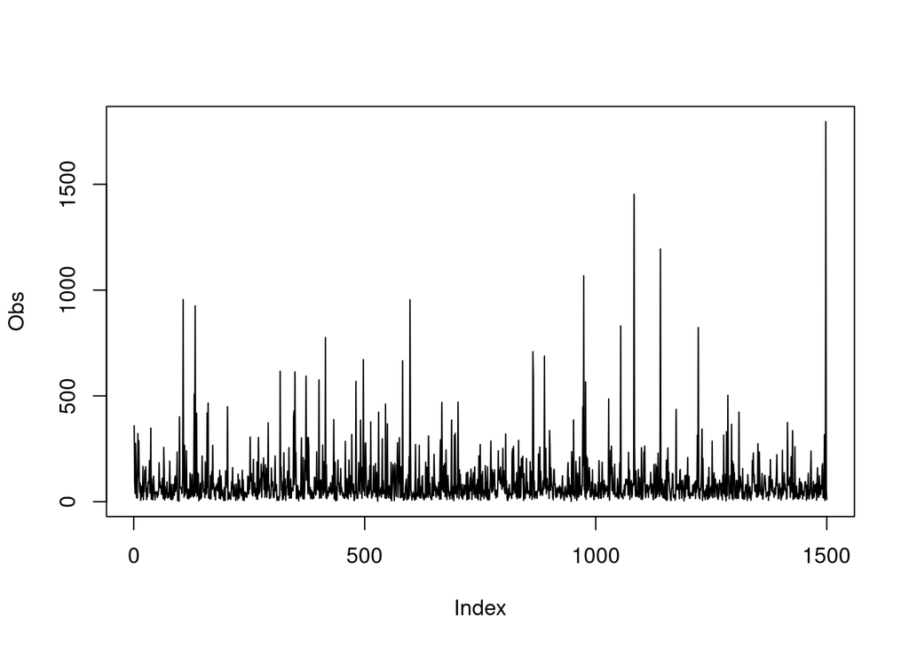

```r
set.seed(54)
n=1500
Obs<- rlnorm(n, 4,1) # muestra de entrenamiento. en mis datos lo debo partir

plot(Obs,type="l")
```

```r
# Paso 1
umbral<-400

exceso<-which(Obs > umbral) # selecciono los valores que son mayores que el umbral definido

# Paso 2
p<- 1 - (length(exceso) / length(Obs)) # Probabilidad de quedar bajo el umbral p=F(u)
p
```

```
## [1] 0.9746667
```

```r
# Paso 3
y<- Obs[exceso] - umbral # Esto es lo que llamamos "evento"
y
```

```
##  [1]    1.3340925  555.5071700  109.0074487  525.5143619   17.9391772
##  [6]   19.1940873   66.4065231   48.6893919  216.6925671    0.2777801
## [11]   29.3269094  213.5074913  193.3120568  175.6659799  375.8097801
## [16]  168.6865985  271.2085668   22.9720653   61.4817975  266.2520807
## [21]  554.3795990   69.2212604   70.8906573  309.1472827  193.8986787
## [26]  287.9624479   48.4823670  667.5580454  165.9932543   85.5365417
## [31]  430.7470354 1053.0294914  794.2472491   36.3814915  423.1936366
## [36]  102.7264802   23.4033107 1396.1851289
```

Con estos pasos, podemos pasar al paso 5, que es fundamental y requiere de pasos extra y que difieren según sean casos *iid* o debilmente estacionarios (más adelante). Recordemos que para evaluar 5, se debe ajustar y evaluar la DGP a los datos seleccionados. Para esto es importante evitar ajustar los parámetros y realizar la evaluación con los **mismos** datos. Para evitar esto se puede utilizar este algoritmo.

1. Se parten los datos en dos subconjuntos, uno *A* de tamaño *d*, y otro *B* de tamaño *n-d*. En datos *iid* la división puede ser sistemática o por sorteo. En general $r<<d<<n-d$
2. Utilizando la submuestra *A* se ajusta la distribución por el método de los cuantiles o momentos. En este caso se ajusta un DGP.
3. Luego, en la submuestra *B* se aplica la prueba de ajuste de Kolmogorov-Smirnov a $F$ asumiendo para los valores de los parámetros las estimaciones obtenidas en *ii*

Para esto utilizaremos el paquete *{POT}*, que tiene varias funciones para trabajar con estas técnicas

```r
require(POT)
# Paso 5
#Separamos la muestra para el test de ajuste
d= 15 # Numero de datos para muestra A (entrenamiento)

selA<- sample(1:length(y), size=d, replace=FALSE)

yA<-y[selA] # Muestra entrenamiento
yB<-y[-selA] # muestra prueba

# Ajusto un modelo de pareto generalizado
GP <- fitgpd(yA, 0) # Umbral=0, por defecto por Maxima verosimilitud
k<-GP$fitted.values["shape"]
sigma<-GP$fitted.values["scale"]

k
```

```
##     shape
## 0.1328033
```

```r
sigma
```

```
##   scale
## 126.052
```

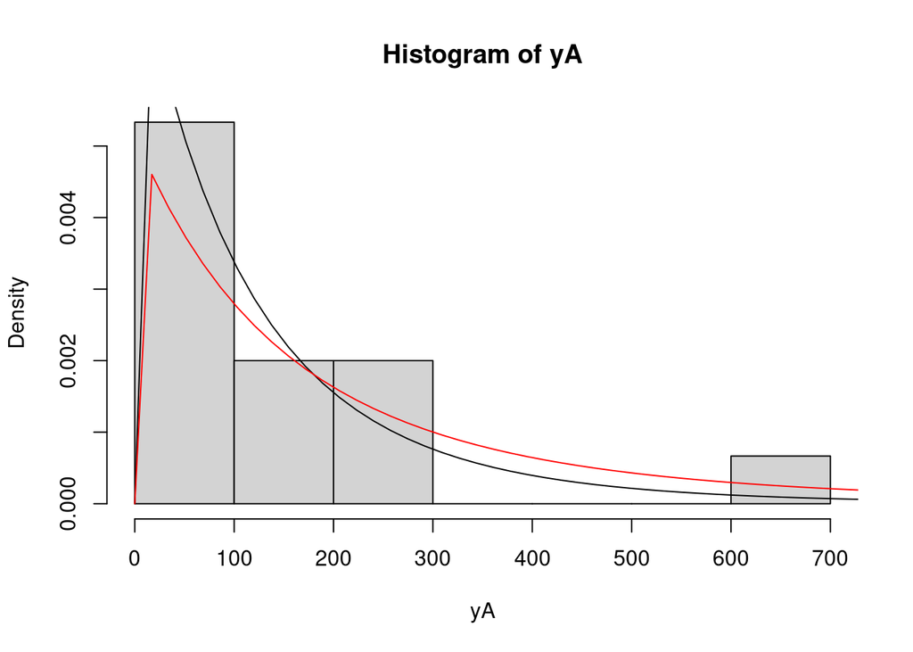

```r
#Probability Weighted Moments- Estimacion por el metodo de los momentos
pwu <- fitgpd(y, 0, "pwmu")
#str(pwu)
sigmaMom<-pwu$fitted.values[1] # scale
kMom<-pwu$fitted.values[2]  # Shape

hist(yA, prob=T)
lines(seq(0,1700, length=100),dgpd(seq(0,1700, length=100), 0, sigma,k))
lines(seq(0,1700, length=100),dgpd(seq(0,1700, length=100), 0, sigmaMom,kMom),col="red")
```

```r
# Test en la muestra no usada para ajustar la GP (muestra B)
#ks.test(rnorm(1000, 0,1), "pnorm", 0,1) # P>0.05 misma distribucion
#ks.test(rnorm(1000, 0,1), rnorm(100,10,1)) # P>0.05 misma distribucion
ks.test(yB ,"pgpd",scale=sigma,shape=k) # ver la ayuda de ?pgpd
```

```
##
##  One-sample Kolmogorov-Smirnov test
##
## data:  yB
## D = 0.39852, p-value = 0.000829
## alternative hypothesis: two-sided
```

```r
ks.test(yB ,"pgpd",scale=sigmaMom,shape=kMom) # ver la ayuda de ?pgpd
```

```
##
##  One-sample Kolmogorov-Smirnov test
##
## data:  yB
## D = 0.23231, p-value = 0.1419
## alternative hypothesis: two-sided
```

Como se aprecia, por el método de máxima verosimilitud, los datos no pasan la prueba K-S de poder ser ajustados por una DPG. Aquí deberíamos ver que cuando ajustamos el programa nos devuelve un aviso (*warning*) de que la optimización puede no ser buena. Mientras que los estimadores generados por el método de los momentos si lo hacen. Continuemos asumiendo que los datos pueden ser modelados adecuadamente con una DPG y ajustemos la distribución a toda la muestra ($\hat {DPG}$).

```r
# Paso 6
# Ajusto GP con toda la data
GPtot <- fitgpd(y, 0) # Umbral=0, por defecto por Maxima verosimilitud
ktot<-GPtot$fitted.values["shape"]
sigmatot<-GPtot$fitted.values["scale"]
sigmatot
```

```
##    scale
## 228.2478
```

```r
ktot
```

```
##     shape
## 0.1634128
```

```r
GPtotMom <- fitgpd(y, 0, "pwmu") # Umbral=0, por defecto por Maxima verosimilitud
GPtotMom$fitted.values[1] # scale
```

```
##    scale
## 194.5685
```

```r
GPtotMom$fitted.values[2] # shape
```

```
##     shape
## 0.2644476
```

Con el modelo ajustado podemos pasar a analizar la distribución de los excesos.

```r
# Paso 7
# estimar la probabilidad de X<=t (F(t)), dado que t>umbral.
# F(X<=t)= p + (1-p) PGE(t-u)

t= 500

# Probabilidad de no exceder un valor mayor a t (t>u)
p + (1-p)* pgpd(t-umbral, 0, unname(sigmatot),unname(ktot))
```

```
## [1] 0.9834071
```

```r
# Probabilidad de exceder t (el complemento)
1 - p + (1-p)* pgpd(t-umbral, 0, unname(sigmatot),unname(ktot))
```

```
## [1] 0.03407379
```

```r
#Compare con el valor calculado de forma empírica
1- sum(Obs<t)/length(Obs)
```

```
## [1] 0.01533333
```

##### Datos débilmente dependientes

Ahora veremos un ejemplo para datos débilmente dependientes y como hacer la evaluación de la DPG.

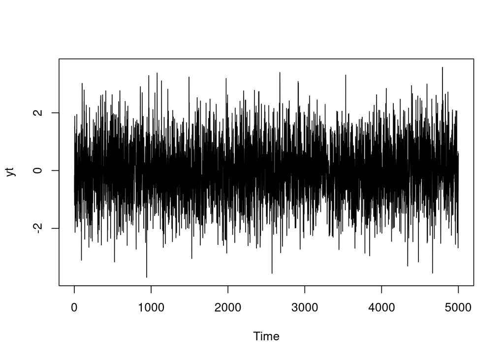

```r
set.seed(54)
yt <- arima.sim(list(order=c(1,0,0), ar=.2), n=5000)
plot(yt)
```

```r
umbral=1.5

exceso<-which(yt > umbral) # selecciono los valores que son mayores que el umbral definido

p<- 1 - (length(exceso) / length(yt)) # Probabilidad de quedar bajo el umbral p=F(u)
p
```

```
## [1] 0.9256
```

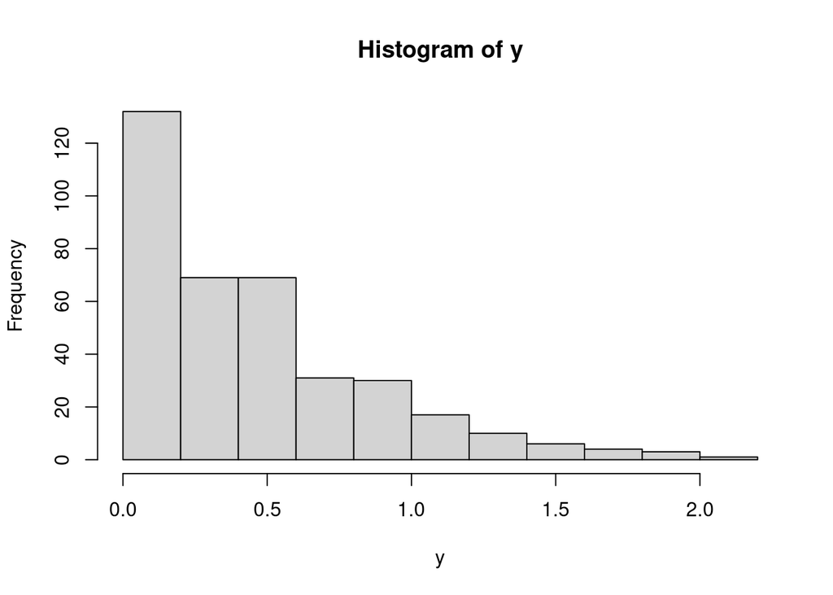

```r
y<- yt[exceso] - umbral # Esto es lo que llamamos "evento"
#y

hist(y)
```

```r
#i Separamos la muestra para el test de ajuste
d= 50 # Numero de datos para muestra A (entrenamiento)

selA<- 1:d

yA<-y[selA] # Muestra entrenamiento
yB<-y[-selA] # muestra prueba

# ii- ajusto a la muestra A por método de los momentos
pwuA <- fitgpd(yA, 0, "pwmu")
sigmaMomA<-pwuA$fitted.values[1] # scale
kMomA<-pwuA$fitted.values[2]  # Shape

sigmaMomA
```

```
##     scale
## 0.7985046
```

```r
kMomA
```

```
##      shape
## -0.5143933
```

```r
# iii
#r=2
k=15
# Separamos en 15 grupos
yBsplit<-split(yB, 0:length(yB) %/% k)
ks.test(yBsplit[[1]] ,"pgpd",scale=sigmaMomA,shape=kMomA)$statistic
```

```
##         D
## 0.3230723
```

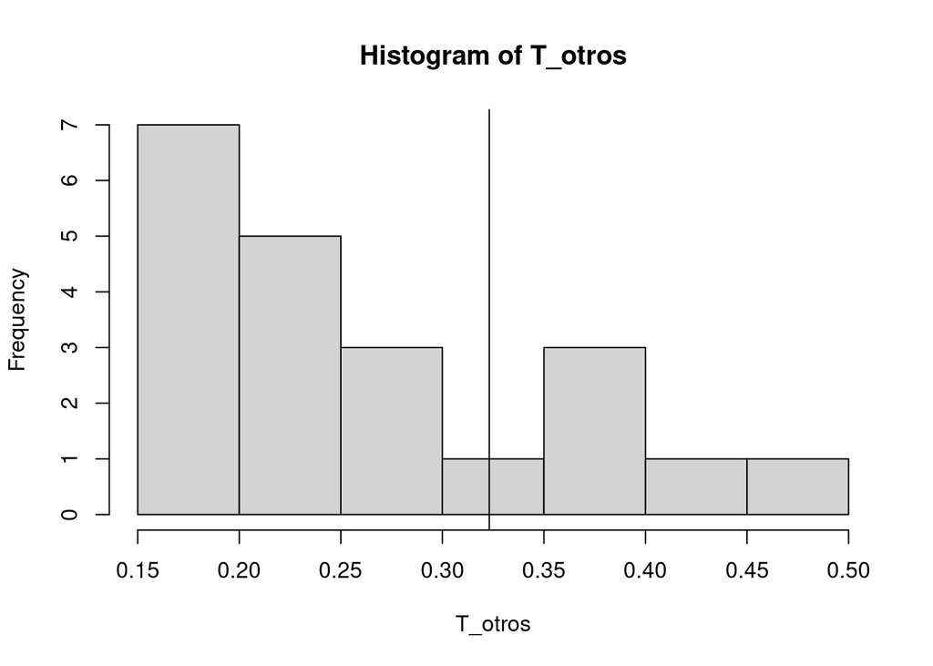

```r
Tes<-unlist(lapply(yBsplit, function(X) ks.test(X ,"pgpd",scale=sigmaMomA,shape=kMomA)$statistic) )

T<-Tes[1]
T_otros<- Tes[-1]

hist(T_otros)
abline(v=T)
```

```r
sum(T>T_otros)/length(T_otros)
```

```
## [1] 0.7619048
```

En resumen, no puedo rechazar $H_0$ y por lo tanto es correcto utilizar una DPG en este caso. Luego debo ajustar el modelo a toda la data.

```r
pwuTot <- fitgpd(y, 0, "pwmu")
sigmaMomTot<-pwuTot$fitted.values[1] # scale
kMomTot<-pwuTot$fitted.values[2]  # Shape

sigmaMomTot
```

```
##     scale
## 0.5063638
```

```r
kMomTot
```

```
##      shape
## -0.1003057
```

[figure not shown]

```r
hist(y, prob=T)
lines(seq(0,1700, length=100),dgpd(seq(0,1700, length=100), 0, sigmaMomTot,kMomTot))
```

## Procesos estacionarios debilmente dependientes

```r
library(TSA)
library(tseries)
```

A continuación consideraremos diferentes procesos con dependencia débil. Apartir de series simuladas de procesos débilmente dependientes, analizaremos la independencia de la serie completa y aquella de los datos sobre un umbral determinado y veremos que sucede. Consideraremos un proceso MA(2) y un AR(1).

Brindamos aquí una brevísima descripción de estos procesos. Comentamos además, que los mismos se ven en detalle en el curso “Herramientas para el análisis de series de tiempo” a cargo de Gonzalo, que se dicta en el segundo semestre de años pares.

Vale repasar aquí muy brevemente la definición de ruido blanco (RB). Un ruido blanco es un proceso aleatorio no correlacionado con media cero y varianza constante.

### Procesos de Media Móvil (MA)

Un proceso de media móvil (de aquí en más los llamaremos MA) es un proceso aleatorio que resulta de la suma de valores sucesivos de ruido blanco. Un MA de orden 1 (MA(1)) es la suma de dos valores sucesivos de un ruido blanco, un MA(2) es la suma de tres valores de ruidos blancos, etc.

Podemos escribir de forma genéica a un proceso MA(q) de la siguiente manera:

$$x_{t}= \varepsilon_{t} + \theta_{1} \varepsilon_{t-1} + \theta_{2} \varepsilon_{t-2} +...+ \theta_{q} \varepsilon_{t-q}$$

Donde los $\varepsilon$ son un ruidos blancos con media cero y una varianza determinada. Notar que si el valor absoluto de los $\theta$ es menor a 1 entonces las innovaciones pasadas influye menos que la actual.

Simulemos un MA(2):

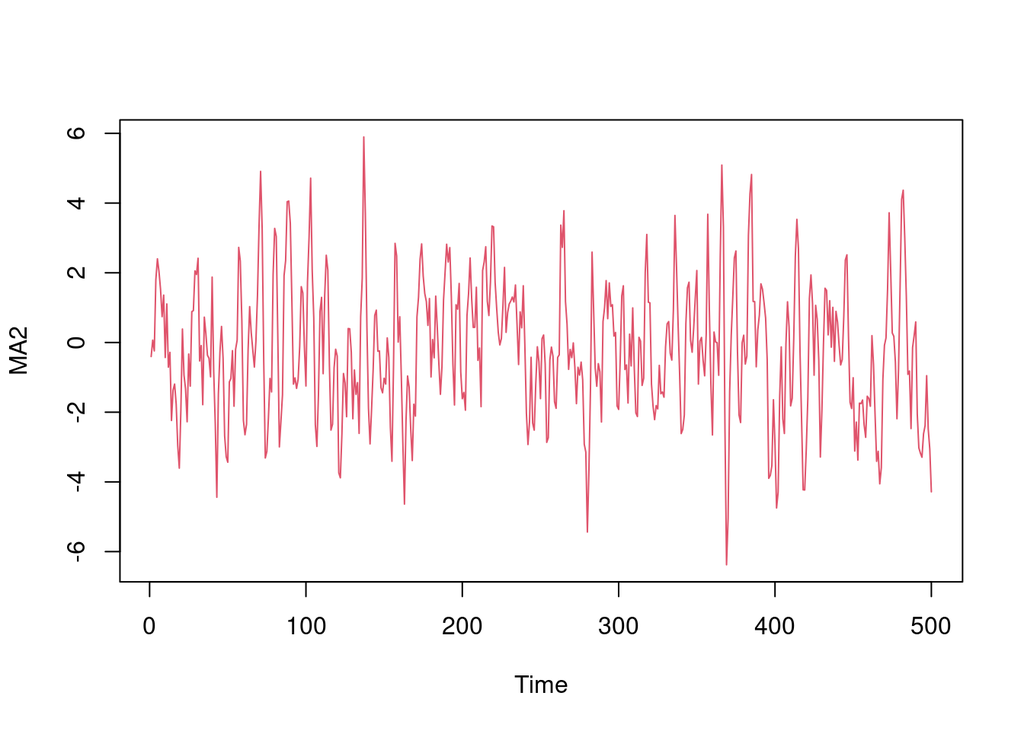

```r
set.seed(101)
MA2=arima.sim(model = list(order = c(0, 0, 2), ma=c(1.2,1.2)),n = 500)
#Al establecer q=2, generamos un proceso MA(2). El valor de los parámetro ma corresponden a los valores que toma el paráemtro ?? mencionado más arriba. Como es un ma de órden 2 debemos especificar 2 valores. Pueden juagar modificando esos valores.
#Graficamos
plot.ts(MA2,col=50)
```

Evaluemos la independencia de la serie con  
un test de rachas. Recuerden que existen varios test para evaluar aleatoriedad, ver el Lab 2 para más ejemplos. Este procedimiento deben realizarlo para todos los casos (incluidos los anteriores).

```r
runs.test(as.factor(MA2>median(MA2))) #esta función requiere factorizar a la variable, generamos dos categorías, una que considere a los valores por encima de la mediana y otra por debajo.
```

```
##
##  Runs Test
##
## data:  as.factor(MA2 > median(MA2))
## Standard Normal = -9.8486, p-value < 2.2e-16
## alternative hypothesis: two.sided
```

El resultado (p-valor muy pequeño) indica que no estamos en condiciones de asumir aleatoriedad en los datos. Veamos que pasa si consideramos datos sobre cierto umbral.

```r
MA2q90=quantile(MA2,0.90)
MA2q90
```

```
##      90%
## 2.350161
```

```r
excesoMA2<-which(MA2 > MA2q90)
excesoMA2
```

```
##  [1]   5  31  57  70  71  72  80  81  88  89  90 102 103 113 137 138 157 158 173
## [20] 174 190 192 205 215 219 220 263 264 265 283 318 336 357 365 366 367 374 375
## [39] 383 384 385 413 414 415 445 446 473 481 482 483
```

Evaluemos la aleatoriedad sobre los excesos.

```r
MA2e=MA2[excesoMA2]
runs.test(as.factor(MA2e>median(MA2e)))
```

```
##
##  Runs Test
##
## data:  as.factor(MA2e > median(MA2e))
## Standard Normal = -0.85732, p-value = 0.3913
## alternative hypothesis: two.sided
```

### Procesos autorregresivos (AR)

Un modelo autorregresivo (AR) es una representación de un proceso aleatorio en el que la variable de interés depende linealmente de sus valores anteriores. En concreto, un AR de orden 1 (AR(1)) se puede expresar como:

$$x_{t}= \phi x_{t-1} + \varepsilon_{t}$$

En este proceso, el valor actual depende linealmente de su valor previo y de un término aleatorio. Es estacionario si el parámetro $\phi$ (a veces también llamado $\rho$), no es muy grande ($\phi$<1). De forma genérica, un proceso AR(p) se puede escribir así:

$$x_{t}= \phi_{1} x_{t-1} + \phi_{2} x_{t-2}+... + \phi_{p} x_{t-p} +\varepsilon_{t}$$

Nuevamente $\varepsilon_{t}$ corresponde a un ruido blanco.

Simulamos a continuación un AR(1).

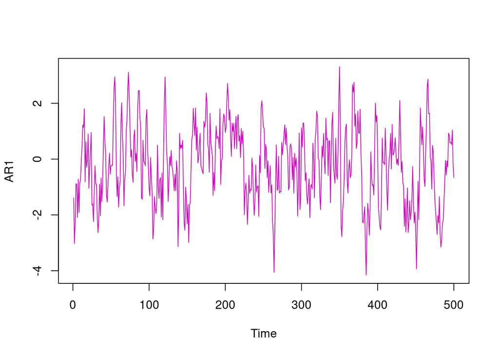

```r
set.seed(101)
AR1=arima.sim(model = list(order = c(1, 0, 0), ar=0.70),n = 500)
#Al establecer p=1, generamos un proceso AR(1). El valor del parámetro ar corresponde al paráemtro Ø. Pueden juagar modificando ese valor.
#Graficamos
plot.ts(AR1,col=22)
```

Hacemos un test de aleatoriedad (Rachas)

```r
runs.test(as.factor(AR1>median(AR1)))
```

```
##
##  Runs Test
##
## data:  as.factor(AR1 > median(AR1))
## Standard Normal = -10.923, p-value < 2.2e-16
## alternative hypothesis: two.sided
```

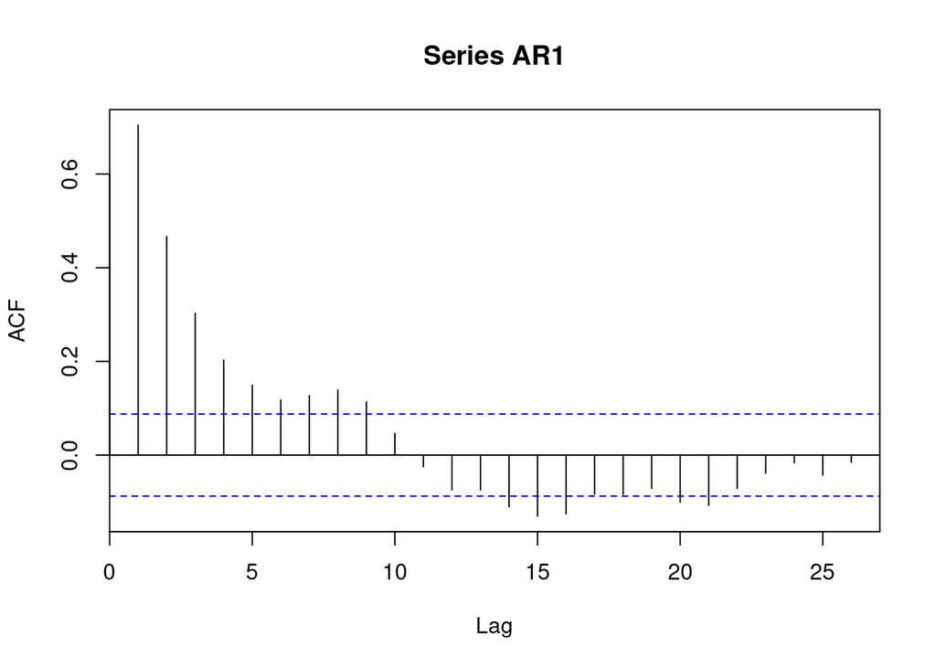

```r
acf(AR1) #el gráfico de autocorrelación nos permite ver como se autocorrelaciona la serie considerando diferentes "lags". Observamos correlaciones significativas a lags bajos.
```

Según el test de rachas, rechazamos H0: datos no aleatorios. Como hicimos con el MA(2), vamos a fijar un umbral y luego correr el test de rachas sobre los excesos del AR(1).

```r
AR1q90=quantile(AR1,0.90)
AR1q90
```

```
##      90%
## 1.524068
```

```r
excesoAR1<-which(AR1 > AR1q90)
excesoAR1
```

```
##  [1]  15  54  55  56  64  72  73  74  85  86  87  97 120 121 122 158 161 175 176
## [20] 180 193 198 202 203 204 206 214 217 247 248 249 320 321 341 349 350 367 368
## [39] 369 371 374 377 397 399 429 456 465 466 467 468
```

Evaluemos la aleatoriedad sobre los excesos.

```r
AR1e=AR1[excesoAR1]
runs.test(as.factor(AR1e>median(AR1e)))
```

[output not shown]

Probemos a subir un poco el umbral

```r
AR1q95=quantile(AR1,0.95)
AR1q95
```

```
##      95%
## 1.987365
```

```r
excesoAR1_2<-which(AR1 > AR1q95)
excesoAR1_2
```

```
##  [1]  54  55  64  72  73  74  86  87 120 121 175 176 202 203 204 248 349 350 367
## [20] 368 369 397 429 465 466
```

Evaluemos la aleatoriedad sobre los excesos considerando como umbral al q95

```r
AR1e_2=AR1[excesoAR1_2]
runs.test(as.factor(AR1e_2>median(AR1e_2)))
```

```
##
##  Runs Test
##
## data:  as.factor(AR1e_2 > median(AR1e_2))
## Standard Normal = 0.62212, p-value = 0.5339
## alternative hypothesis: two.sided
```

##### Datos reales

```r
data<-read.csv("data_LAB_POT.csv")
summary(data)
```

```
##       time             cf
##  Min.   :  1.0   Min.   :     5
##  1st Qu.:234.5   1st Qu.:   150
##  Median :468.0   Median :   400
##  Mean   :468.0   Mean   :  1358
##  3rd Qu.:701.5   3rd Qu.:   870
##  Max.   :935.0   Max.   :153000
```

```r
cf<-log(data$cf) + runif(nrow(data), 0.1,0.2) # agrego uniforme pequeña para evitar empates (no modifica el resultado)

umbral<- log(2000)

exceso<-which(cf> umbral) # selecciono los valores que son mayores que el umbral definido

p<- 1 - (length(exceso) / length(cf)) # Probabilidad de quedar bajo el umbral p=F(u)
p
```

```
## [1] 0.8855615
```

```r
y<- cf[exceso] - umbral # Esto es lo que llamamos "evento"
y
```

```
##   [1] 0.954509154 0.886949140 0.810381851 0.245087341 0.159582947 0.918627084
##   [7] 0.617123897 0.065851596 0.615029867 0.040806033 0.120433029 0.200392994
##  [13] 0.137023427 0.300333268 1.208477954 0.405847821 1.273479812 1.444639561
##  [19] 1.219130881 0.169574901 0.630351715 3.230668456 4.499430112 2.413849949
##  [25] 0.905536016 0.358491841 2.099673944 0.442998099 0.129818224 0.370732364
##  [31] 1.715322804 1.113601349 0.207496182 1.056492134 0.139504382 1.333800669
##  [37] 0.282035134 0.605739672 0.273167851 0.710543464 2.136823093 1.958738981
##  [43] 0.248611569 0.532526876 0.007922861 0.200729041 1.362715306 0.189201758
##  [49] 0.182355318 0.849263935 0.488342098 1.563274870 0.172865536 0.749822479
##  [55] 0.406241683 0.380716467 0.225837628 0.327565314 0.268276508 0.048550002
##  [61] 0.160418256 0.748168120 0.200514619 0.150440427 0.001298235 0.208636489
##  [67] 0.219029503 4.359642525 1.711841909 0.924712035 2.187565083 0.076594247
##  [73] 0.078876697 1.068773109 0.042385954 0.922547503 0.731214586 0.703724546
##  [79] 0.635898839 0.806857145 0.295250269 0.516928256 0.027102794 0.245077414
##  [85] 1.566453498 0.375512455 1.206326824 0.061644136 0.103310520 0.132188978
##  [91] 1.606122566 0.013294511 1.752127348 2.967776953 0.480992124 0.014240558
##  [97] 1.898324056 0.205006270 3.687346490 0.635508960 3.493541730 1.456316753
## [103] 1.055905027 0.493865292 0.598453375 0.638763601 0.500975186
```

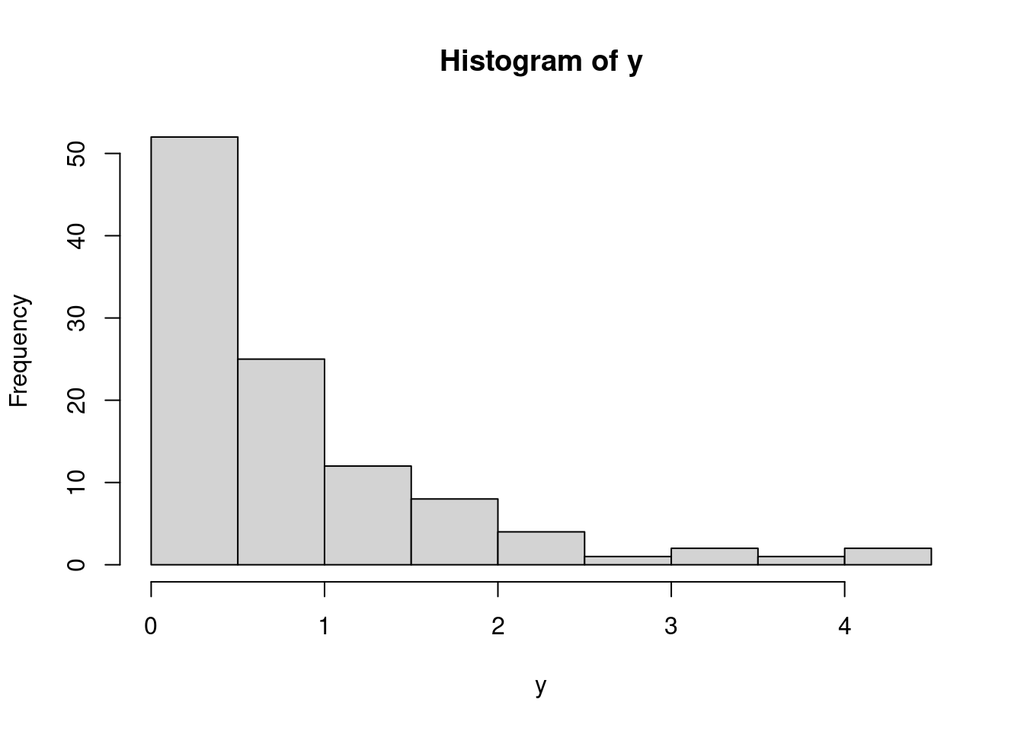

```r
hist(y)
```

```r
#i Separamos la muestra para el test de ajuste
d= 50 # Numero de datos para muestra A (entrenamiento)

selA<- 1:d

yA<-y[selA] # Muestra entrenamiento
yB<-y[-selA] # muestra prueba

# ii- ajusto a la muestra A por método de los momentos
pwuA <- fitgpd(yA, 0, "pwmu")
sigmaMomA<-pwuA$fitted.values[1] # scale
kMomA<-pwuA$fitted.values[2]  # Shape

sigmaMomA
```

```
##     scale
## 0.7766704
```

```r
kMomA
```

```
##      shape
## 0.07498332
```

```r
# iii
#r=2
k=7
# Separamos en k grupos
yBsplit<-split(yB, 0:length(yB) %/% k)
ks.test(yBsplit[[1]] ,"pgpd",scale=sigmaMomA,shape=kMomA)$statistic
```

```
##         D
## 0.2552557
```

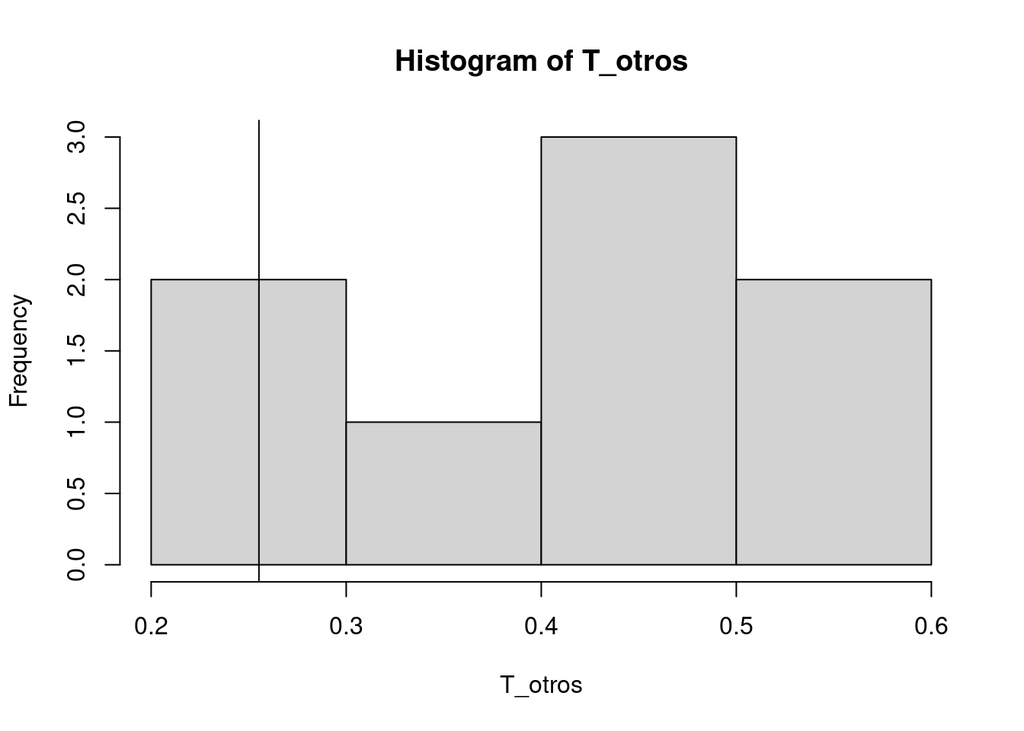

```r
Tes<-unlist(lapply(yBsplit, function(X) ks.test(X ,"pgpd",scale=sigmaMomA,shape=kMomA)$statistic) )

T<-Tes[1]
T_otros<- Tes[-1]

hist(T_otros)
abline(v=T)
```

```r
sum(T>T_otros)/length(T_otros)
```

```
## [1] 0.125
```

```r
# Ajusto a toda la serie
DPGDatos <- fitgpd(y, 0, "pwmu")
```

### Ejercicio

Por favor, simule una serie estacional con alta varianza respecto a las oscilaciones y estime la DPG de los excesos en base a un umbral que usted defina.

Realice las pruebas necesarias para evaluar si el modelo es adecuado.

Calcule el valor de la probabilidad empírica y acorde al modelo de exceder un valor que defina más alto que el umbral escogido.